# Course Demonstrations

Lifetime Physical Activity Training

2025-09-09

## Compilations of Course Demonstrations

This is a simple document that contains all the practical demonstrations you will find in the Systematic Review and Meta - Analysis Course. Click on the copy button at the left corner of each of the cells to copy the codes. Paste the codes in you R studio in order to also reproduce the similar outcome.

## Lecture 3.1 Demonstration: Handling Missing Data

This is an set of r code for applying mean imputation, Last Observation Carried Forward (LOCF), and multiple imputation using a simulated dataset with missing values.

*Install the following packages if not already installed*

install.packages(c(“mice”, “zoo”, “dplyr”))

mice - For multiple imputation

zoo - For LOCF

dplyr - For data manipulation

```r
library(mice)
library(zoo)
library(dplyr)
```

**Simulate Dataset with Missing Values**

Here we are going to stimulate a sample dataset. But you can import your own dataset at this point if you have a dataset in this regard.

**Note:** the NA means missing data

```r
set.seed(123)
data <- data.frame(
  ID = 1:10,
  Age = c(25, 30, NA, 45, 50, NA, 60, 65, 70, NA),
  BP  = c(120, NA, 130, 135, NA, 140, 145, NA, 150, 155)
)
```

**Print the dataset for a visual inspection**

```r
print(data)
```

```
##    ID Age  BP
## 1   1  25 120
## 2   2  30  NA
## 3   3  NA 130
## 4   4  45 135
## 5   5  50  NA
## 6   6  NA 140
## 7   7  60 145
## 8   8  65  NA
## 9   9  70 150
## 10 10  NA 155
```

**Mean Imputation**

Impute missing values with column means

```r
data_mean_imp <- data %>%
  mutate(
    Age = ifelse(is.na(Age), mean(Age, na.rm = TRUE), Age),
    BP  = ifelse(is.na(BP), mean(BP, na.rm = TRUE), BP)
  )
```

**After Mean Imputation:**

```r
print(data_mean_imp)
```

```
##    ID      Age       BP
## 1   1 25.00000 120.0000
## 2   2 30.00000 139.2857
## 3   3 49.28571 130.0000
## 4   4 45.00000 135.0000
## 5   5 50.00000 139.2857
## 6   6 49.28571 140.0000
## 7   7 60.00000 145.0000
## 8   8 65.00000 139.2857
## 9   9 70.00000 150.0000
## 10 10 49.28571 155.0000
```

**Last Observation Carried Forward (LOCF)**

Apply LOCF for each column

```r
data_locf <- data %>%
  mutate(
    Age = na.locf(Age, na.rm = FALSE),
    BP  = na.locf(BP, na.rm = FALSE)
  )
```

**After LOCF Imputation:**

```r
print(data_locf)
```

```
##    ID Age  BP
## 1   1  25 120
## 2   2  30 120
## 3   3  30 130
## 4   4  45 135
## 5   5  50 135
## 6   6  50 140
## 7   7  60 145
## 8   8  65 145
## 9   9  70 150
## 10 10  70 155
```

**Multiple Imputation (Using mice)**

Perform multiple imputation

```r
imp <- mice(data, m = 5, method = 'pmm', seed = 500)
```

**Check imputed data**

```r
summary(imp)
```

```
## Class: mids
## Number of multiple imputations:  5
## Imputation methods:
##    ID   Age    BP
##    "" "pmm" "pmm"
## PredictorMatrix:
##     ID Age BP
## ID   0   1  1
## Age  1   0  1
## BP   1   1  0
```

**Complete the first imputed dataset**

```r
data_mice <- complete(imp, 1)
```

**After Multiple Imputation (First Dataset):**

```r
print(data_mice)
```

```
##    ID Age  BP
## 1   1  25 120
## 2   2  30 140
## 3   3  45 130
## 4   4  45 135
## 5   5  50 135
## 6   6  45 140
## 7   7  60 145
## 8   8  65 145
## 9   9  70 150
## 10 10  60 155
```

## Lecture 3.2 Demonstration: Exploring Heterogeneity in Systematic Review Data

This demonstration is on exploring heterogeneity in meta - analysis.

**Load the required package**

```r
library(metafor)
```

**Simulating 10 studies with random true effects + sampling error**

```r
set.seed(123)
k <- 10
true_effects <- rnorm(k, mean = 0.3, sd = 0.2)  # true effects vary across studies
se <- runif(k, min = 0.08, max = 0.20)          # random standard errors
observed_effects <- rnorm(k, mean = true_effects, sd = se)
```

**Put into a dataframe**

```r
data <- data.frame(
  study_id = paste0("Study_", 1:k),
  effect_size = observed_effects,
  se = se
)
```

**Print data**

```r
print(data)
```

```
##    study_id effect_size         se
## 1   Study_1  0.52160146 0.18674472
## 2   Study_2  0.33518204 0.16313641
## 3   Study_3  0.30325649 0.15686082
## 4   Study_4  0.45389059 0.19931237
## 5   Study_5  0.25083279 0.15868470
## 6   Study_6  0.46679683 0.16502366
## 7   Study_7  0.36051412 0.14528792
## 8   Study_8 -0.10824369 0.15129704
## 9   Study_9  0.07902621 0.11469917
## 10 Study_10  0.14983025 0.09765364
```

**Random-effects meta-analysis**

```r
res <- rma(yi = effect_size, sei = se, data = data, method = "REML")
```

**Summary of results**

```r
summary(res)
```

```
##
## Random-Effects Model (k = 10; tau^2 estimator: REML)
##
##   logLik  deviance       AIC       BIC      AICc
##   1.9900   -3.9799    0.0201    0.4145    2.0201
##
## tau^2 (estimated amount of total heterogeneity): 0.0136 (SE = 0.0167)
## tau (square root of estimated tau^2 value):      0.1167
## I^2 (total heterogeneity / total variability):   38.93%
## H^2 (total variability / sampling variability):  1.64
##
## Test for Heterogeneity:
## Q(df = 9) = 14.6136, p-val = 0.1021
##
## Model Results:
##
## estimate      se    zval    pval   ci.lb   ci.ub
##   0.2533  0.0600  4.2188  <.0001  0.1356  0.3710  ***
##
## ---
## Signif. codes:  0 '***' 0.001 '**' 0.01 '*' 0.05 '.' 0.1 ' ' 1
```

**Extract heterogeneity statistics**

```r
Q <- res$QE
Q_pval <- res$QEp
I2 <- res$I2
H2 <- res$H2

cat("Cochran's Q =", Q, "with p-value =", Q_pval, "\n")
```

```
## Cochran's Q = 14.61357 with p-value = 0.1021124
```

```r
cat("I-squared =", I2, "%\n")
```

```
## I-squared = 38.93462 %
```

```r
cat("H-squared =", H2, "\n")
```

```
## H-squared = 1.637589
```

**Forest plot**

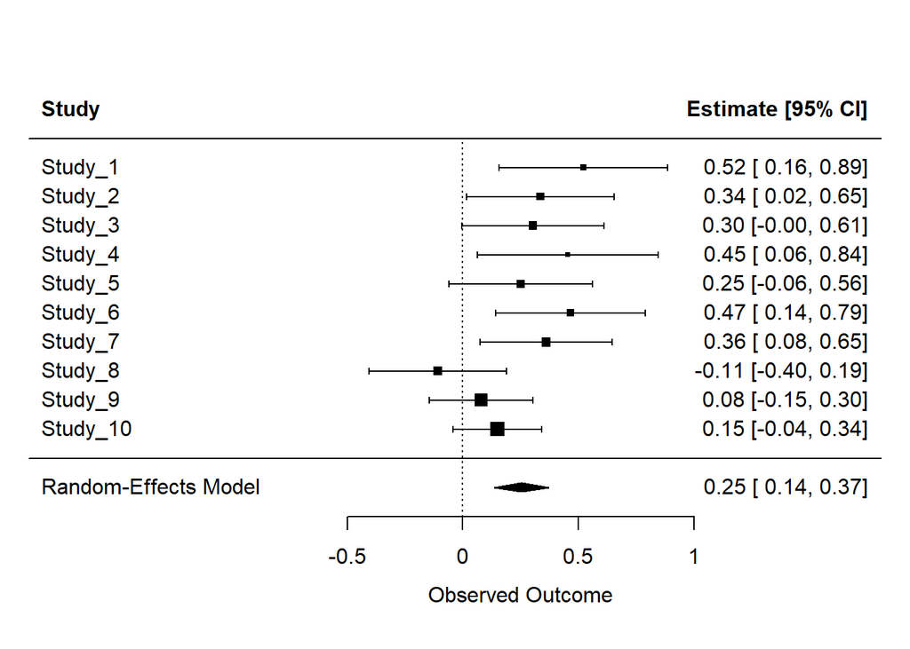

```r
forest(res, slab = data$study_id)
```

## Lecture 3.3 Demonstration: Effect size in Meta - Analysis

This demonstration highlights effect size calculation for meta - analysis

**Loading required library**

Note that you will have to install the package before loading it.

```r
library(meta)
```

**Load the sample dataset**

You can simply load the dataset using this line of code

*sample1 <- Module_3C_sample1*

```r
sample1 <- data.frame(
  study = c("study1", "study2", "study3", "study4", "study5"),
  m1 = c(47, 49, 49, 47, 49),
  s1 = c(11, 11, 14, 10, 11),
  n1 = c(60, 65, 40, 200, 50),
  m2 = c(46, 46, 44, 41, 44),
  s2 = c(10, 11, 13, 9, 11),
  n2 = c(60, 65, 40, 200, 45)
)
```

**Calculate the effect size**

```r
meta1 <- metacont(n1, m1, s1, n2, m2, s2, sm="SMD", study, data=sample1)
meta1
```

```
## Number of studies: k = 5
## Number of observations: o = 825 (o.e = 415, o.c = 410)
##
##                         SMD           95%-CI    z  p-value
## Common effect model  0.4453 [0.3068; 0.5839] 6.30 < 0.0001
## Random effects model 0.3897 [0.1789; 0.6004] 3.62   0.0003
##
## Quantifying heterogeneity (with 95%-CIs):
##  tau^2 = 0.0276 [0.0000; 0.3057]; tau = 0.1662 [0.0000; 0.5529]
##  I^2 = 50.1% [0.0%; 81.7%]; H = 1.42 [1.00; 2.34]
##
## Test of heterogeneity:
##     Q d.f. p-value
##  8.02    4  0.0909
##
## Details of meta-analysis methods:
## - Inverse variance method
## - Restricted maximum-likelihood estimator for tau^2
## - Q-Profile method for confidence interval of tau^2 and tau
## - Calculation of I^2 based on Q
## - Hedges' g (bias corrected standardised mean difference; using exact formulae)
```

**Forest plot**

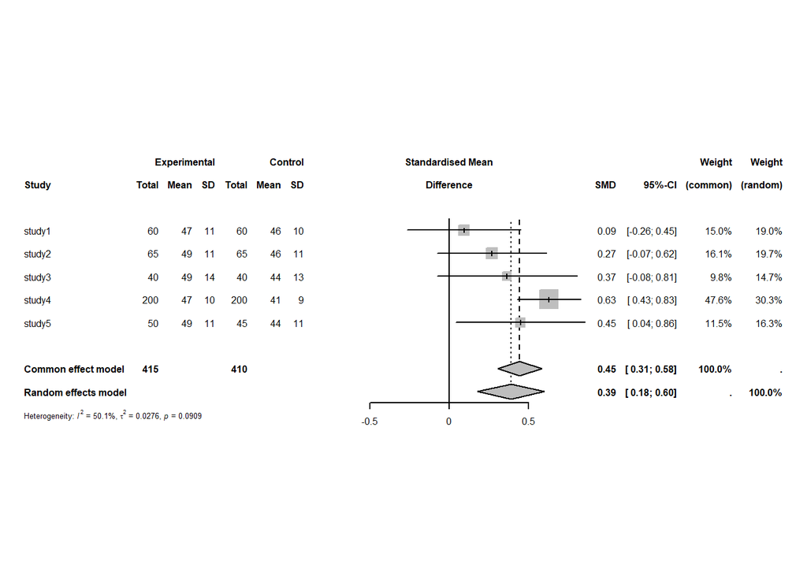

```r
forest(meta1, digits.mean=0, digits.sd=0, fontsize = 6) # Default forest plot
```

## Lecture 4.1 Demonstration: Cleaning, and Structuring Data for Meta-Analysis in R

This demonstration will highlight data cleaning before embarking on any further meta - analysis. In this demonstration, we will delete missing data instead of imputation methods emplored in Lecture 3.1.

**Load data**

Here we are going to generate the sample dataset using r codes. But you can import the dataset directly and follow along with the demonstration or use this approach.

```r
sample2 <- data.frame(
  Study_ID = c("S1", "S2", "S3", "S4", "S5"),
  Effect_Size = c(0.23, 0.45, NA, 0.67, 0.34),
  Variance = c(0.05, 0.07, 0.06, NA, 0.04),
  Sample_Size = c(100, 150, 120, 130, 200),
  Intervention_Type = c("A", "B", "A", "B", "A")
)
```

**Print original dataset**

```r
print(sample2)
```

```
##   Study_ID Effect_Size Variance Sample_Size Intervention_Type
## 1       S1        0.23     0.05         100                 A
## 2       S2        0.45     0.07         150                 B
## 3       S3          NA     0.06         120                 A
## 4       S4        0.67       NA         130                 B
## 5       S5        0.34     0.04         200                 A
```

**Load required library**

```r
library(dplyr)
```

**Load required library**

```r
df_clean <- sample2 %>%
  # Remove rows with missing effect sizes or variances
  filter(!is.na(Effect_Size), !is.na(Variance))

# This ensures meta-analysis models run correctly without errors
```

**Structuring variables**

```r
df_clean <- df_clean %>%
  mutate(Intervention_Type = factor(Intervention_Type))
```

**Print cleaned dataset**

```r
print(df_clean)
```

```
##   Study_ID Effect_Size Variance Sample_Size Intervention_Type
## 1       S1        0.23     0.05         100                 A
## 2       S2        0.45     0.07         150                 B
## 3       S5        0.34     0.04         200                 A
```

## Lecture 4.2 Demonstration: Pooled Prevalence Estimation

This demonstration focuses on how to generate pooled prevalence from group of studies.

**Load data**

```r
data <- data.frame(
  study = c("Umeh & Nkombua, 2018", "Shiriyedeve et al., 2019", "Peter et al., 2022", "Oyewole et al., 2014", "Oyeyemi et al., 2013", "Dimore et al., 2023", "Wonde et al., 2022","Banson et al., 2023","Mwimo et al., 2021","Edmealem et al., 2020", "Adeniyi et al., 2014", "Taylor et al., 2023", "Oyewole et al., 2015", "Enyew et al., 2023", "Nti et al., 2016", "Adeniyi et al., 2016"),
  events = c(53, 77, 83, 82, 641, 54, 173, 46, 307, 222, 62, 39, 82, 210, 40, 92),
  sample_size = c(150, 170, 131, 119, 934, 305, 368, 84, 325, 332, 122, 97, 119, 302, 120, 185),
  country = c("South Africa", "Botswana", "Ghana", "Nigeria", "Nigeria", "Ethiopia", "Ethiopia", "Ghana","Tanzania", "Ethiopia", "Nigeria", "Ghana", "Nigeria", "Ethiopia", "Ghana", "Nigeria")
)
```

**Calculate prevalence and 95%CI for each study**

```r
data$prevalence <- data$events / data$sample_size
data$lower_CI <- data$prevalence - 1.96 * sqrt((data$prevalence * (1 - data$prevalence)) / data$sample_size)
data$upper_CI <- data$prevalence + 1.96 * sqrt((data$prevalence * (1 - data$prevalence)) / data$sample_size)
```

**Meta - analysis for pooled prevalence**

```r
meta_analysis <- metaprop(
  event = data$events,              # Number of events (cases)
  n = data$sample_size,             # Sample size for each study
  studlab = data$study,             # Study labels
  comb.fixed = FALSE,                # Fixed-effect model
  comb.random = TRUE,               # Random-effects model
  sm = "PLOGIT"                     # Use logit transformation for prevalence
)
```

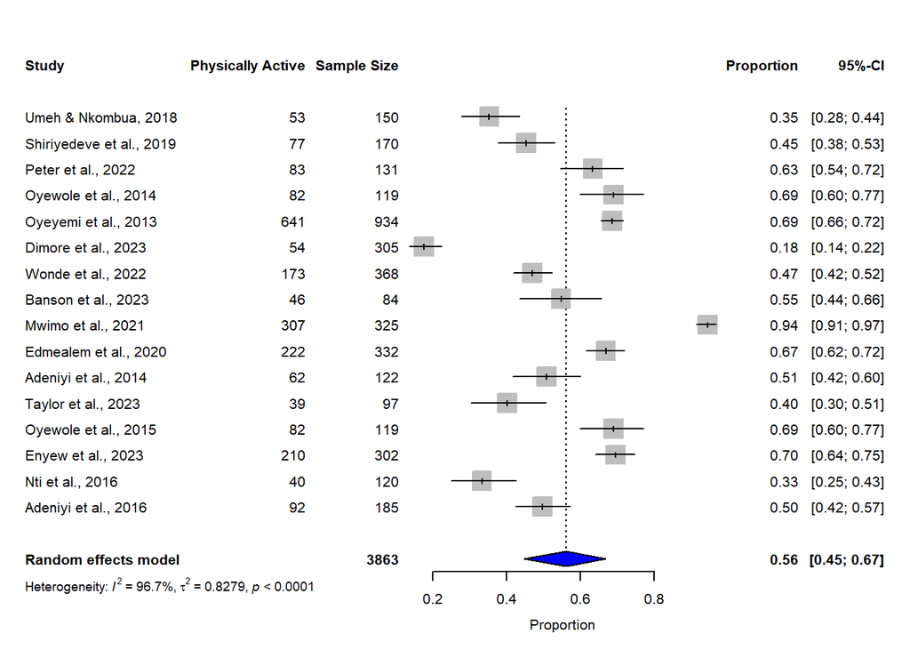

```r
forest(meta_analysis,
       studlab = TRUE,
       xlab = "Proportion",
       leftcols = c("studlab", "event", "n"),
       leftlabs = c("Study", "Physically Active", "Sample Size"),
       rightlabs = c("Weight"),
       col.diamond = "blue",
       col.predict = "darkgreen",
       fontsize = 8)
```

## Lecture 4.3 Demonstration: Pre-Post Comparison Meta - Analysis

This demonstration focuses analyzing continuous data in studies comparing two groups before and after an intervention.

**Load required library**

```r
library(metafor)
```

**Load data**

```r
data <- data.frame(
  study = paste("Study", 1:5),
  m_pre_treat = c(50, 45, 60, 55, 52),
  m_post_treat = c(60, 50, 70, 63, 59),
  sd_pre_treat = c(10, 12, 11, 13, 12),
  sd_post_treat = c(9, 11, 10, 12, 11),
  n_treat = c(30, 28, 32, 25, 29),
  m_pre_control = c(51, 46, 61, 54, 53),
  m_post_control = c(52, 47, 62, 55, 54),
  sd_pre_control = c(9, 10, 10, 11, 10),
  sd_post_control = c(8, 9, 9, 10, 9),
  n_control = c(30, 28, 31, 26, 28)
)
```

**Calculate mean change and SD for each group**

```r
data$mean_change_treat <- data$m_post_treat - data$m_pre_treat
data$mean_change_control <- data$m_post_control - data$m_pre_control
```

**Pooled SD**

```r
data$pooled_sd <- sqrt(((data$n_treat - 1) * data$sd_post_treat^2 +
                        (data$n_treat - 1) * data$sd_pre_treat^2 +
                        (data$n_control - 1) * data$sd_post_control^2 +
                        (data$n_control - 1) * data$sd_pre_control^2) /
                        (2 * (data$n_treat + data$n_control - 2)))
```

**Effect size (Cohen’s d)**

```r
data$es <- (data$mean_change_treat - data$mean_change_control) / data$pooled_sd
```

**Standard error**

```r
data$se <- sqrt((2 / data$n_treat) + (2 / data$n_control))
```

**Run meta-analysis**

```r
res <- rma(yi = data$es, sei = data$se, method = "REML", data = data)
```

**Summary**

```r
summary(res)
```

```
##
## Random-Effects Model (k = 5; tau^2 estimator: REML)
##
##   logLik  deviance       AIC       BIC      AICc
##  -0.6761    1.3521    5.3521    4.1247   17.3521
##
## tau^2 (estimated amount of total heterogeneity): 0 (SE = 0.0985)
## tau (square root of estimated tau^2 value):      0
## I^2 (total heterogeneity / total variability):   0.00%
## H^2 (total variability / sampling variability):  1.00
##
## Test for Heterogeneity:
## Q(df = 4) = 1.8698, p-val = 0.7597
##
## Model Results:
##
## estimate      se    zval    pval   ci.lb   ci.ub
##   0.6997  0.1670  4.1908  <.0001  0.3725  1.0270  ***
##
## ---
## Signif. codes:  0 '***' 0.001 '**' 0.01 '*' 0.05 '.' 0.1 ' ' 1
```

**Forest Plot**

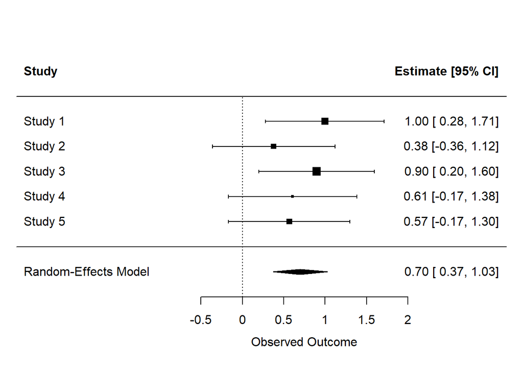

```r
forest(res, slab = data$study)
```

**Understanding the Scale**

0 on the x-axis = no change (before and after means are equal).

Positive values (>0) = the outcome increased after the intervention.

Negative values (<0) = the outcome decreased after the intervention.

**Individual Studies**

Study 1 (1.00 [0.28, 1.71]):

Mean difference ~+1.0, CI does not cross 0 → significant increase after intervention.

Study 2 (0.38 [-0.36, 1.12]):

Mean difference +0.38, CI crosses 0 → not significant.

Study 3 (0.90 [0.20, 1.60]):

Mean difference +0.90, CI excludes 0 → significant increase after intervention.

Study 4 (0.61 [-0.17, 1.38]):

Mean difference +0.61, CI crosses 0 → not significant.

Study 5 (0.57 [-0.17, 1.30]): Mean difference +0.57, CI crosses 0 → not significant.

**Pooled Estimate (Random-Effects Model)**

Overall mean difference = 0.70 [0.37, 1.03].

Since the 95% CI does not include 0, this indicates a statistically significant increase in the continuous outcome after intervention.

*The intervention led to a statistically significant average improvement of 0.70 units across studies, though not all individual studies reached significance.*

## Lecture 4.4 Demonstration: Single Group Pre - Post data

This demonstration focuses analyzing continuous data from a single group before and after an intervention.

**Load required library**

```r
library(metafor)
```

**Load data**

```r
data <- data.frame(
  study = paste("Study", 1:5),
  m_pre = c(50, 55, 52, 60, 58),
  m_post = c(60, 62, 58, 66, 64),
  sd_pre = c(10, 12, 11, 13, 12),
  sd_post = c(9, 11, 10, 12, 11),
  n = c(30, 28, 32, 25, 29)

)
```

**Assume a pre-post correlation (e.g., 0.7)**

```r
r = 0.7
```

**Calculate standardized mean change using Morris & DeShon (2002) method**

```r
data$sd_diff <- sqrt(data$sd_pre^2 + data$sd_post^2 - 2 * r * data$sd_pre * data$sd_post)
data$mean_diff <- data$m_post - data$m_pre
data$smc <- data$mean_diff / data$sd_diff
data$var_smc <- (1 / data$n) + (data$smc^2 / (2 * data$n))
```

**Run meta-analysis**

```r
res <- rma(yi = smc, vi = var_smc, data = data, method = "REML")
```

**Summary**

```r
summary(res)
```

```
##
## Random-Effects Model (k = 5; tau^2 estimator: REML)
##
##   logLik  deviance       AIC       BIC      AICc
##  -0.5034    1.0067    5.0067    3.7793   17.0067
##
## tau^2 (estimated amount of total heterogeneity): 0.0147 (SE = 0.0435)
## tau (square root of estimated tau^2 value):      0.1212
## I^2 (total heterogeneity / total variability):   23.83%
## H^2 (total variability / sampling variability):  1.31
##
## Test for Heterogeneity:
## Q(df = 4) = 5.9495, p-val = 0.2029
##
## Model Results:
##
## estimate      se    zval    pval   ci.lb   ci.ub
##   0.8030  0.1110  7.2316  <.0001  0.5854  1.0207  ***
##
## ---
## Signif. codes:  0 '***' 0.001 '**' 0.01 '*' 0.05 '.' 0.1 ' ' 1
```

**forest Plot**

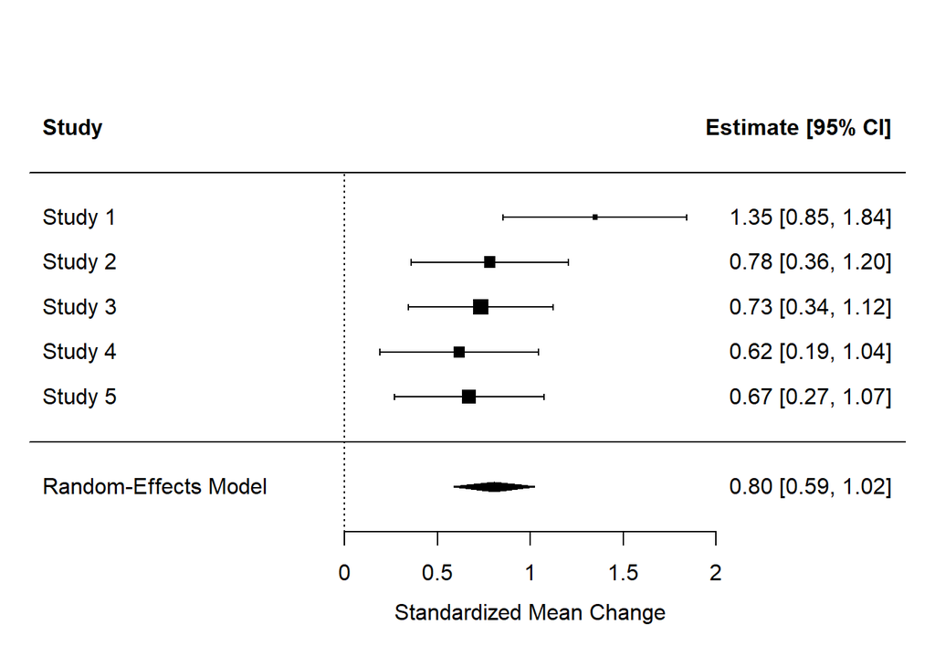

```r
forest(res, slab = data$study, xlab = "Standardized Mean Change")
```

## Lecture 4.5 Demonstration: Binary Data for a Post-Test Only Design

This demonstration focuses analyzing binary data in a post-test-only design. In this type of study, outcomes are measured only after the intervention, making it a common approach when baseline data are unavailable.

**Load required library**

```r
library(metafor)
```

**Load data**

```r
data <- data.frame(
  Study = c("A", "A", "B", "B", "C", "C"),
  Group = c("Control", "Treatment", "Control", "Treatment","Control", "Treatment"),
  Events = c(10, 20, 5, 18, 12, 25),
  Total = c(100, 100, 80, 90, 110, 100)
)
```

**Reshape data**

```r
library(dplyr)
wide_data <- data %>%
  tidyr::pivot_wider(names_from = Group, values_from = c(Events, Total))
```

**Meta-analysis using odds ratio**

```r
meta_result <- metabin(
  event.e = wide_data$Events_Treatment,
  n.e = wide_data$Total_Treatment,
  event.c = wide_data$Events_Control,
  n.c = wide_data$Total_Control,
  studlab = wide_data$Study,
  sm = "OR",  # OR = Odds Ratio, use "RR" for Risk Ratio
  method = "Inverse",
  method.tau = "DL", # DerSimonian-Laird for random effects
  comb.fixed = TRUE,
  comb.random = TRUE,
  fontsize = 8
)
```

**Print summary**

```r
summary(meta_result)
```

```
##       OR            95%-CI %W(common) %W(random)
## A 2.2500 [0.9943;  5.0915]       35.8       35.8
## B 3.7500 [1.3225; 10.6334]       22.0       22.0
## C 2.7222 [1.2844;  5.7695]       42.3       42.3
##
## Number of studies: k = 3
## Number of observations: o = 580 (o.e = 290, o.c = 290)
## Number of events: e = 90
##
##                          OR           95%-CI    z  p-value
## Common effect model  2.7282 [1.6741; 4.4461] 4.03 < 0.0001
## Random effects model 2.7282 [1.6741; 4.4461] 4.03 < 0.0001
##
## Quantifying heterogeneity (with 95%-CIs):
##  tau^2 = 0 [0.0000; 2.2149]; tau = 0 [0.0000; 1.4882]
##  I^2 = 0.0% [0.0%; 89.6%]; H = 1.00 [1.00; 3.10]
##
## Test of heterogeneity:
##     Q d.f. p-value
##  0.57    2  0.7513
##
## Details of meta-analysis methods:
## - Inverse variance method
## - DerSimonian-Laird estimator for tau^2
## - Jackson method for confidence interval of tau^2 and tau
## - Calculation of I^2 based on Q
```

**Forest plot**

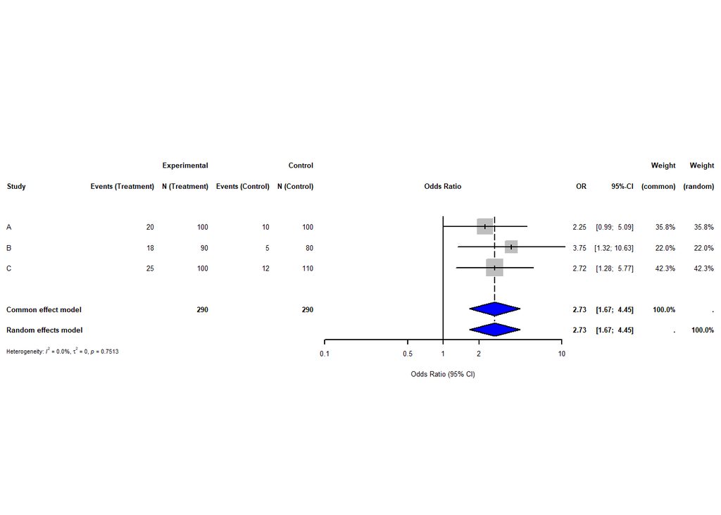

```r
forest(meta_result,
       xlab = "Odds Ratio (95% CI)",
       leftcols = c("studlab", "event.e", "n.e", "event.c", "n.c"),
       leftlabs = c("Study", "Events (Treatment)", "N (Treatment)",
                    "Events (Control)", "N (Control)"),
       col.diamond = "blue",
       col.predict = "darkgreen",
       fontsize = 5   # <-- set font size here
)
```

**Understanding the Scale**

OR = 1.0 → No difference between experimental and control groups.

OR > 1.0 → Higher odds of the event in the experimental group.

OR < 1.0 → Lower odds of the event in the experimental group.

**Individual Studies**

Study A (OR = 2.25, 95% CI: 0.99 – 5.09, weight ~36%)

The intervention group had more than twice the odds of the event compared to control. CI just barely includes 1 → borderline statistical significance.

Study B (OR = 3.75, 95% CI: 1.32 – 10.63, weight ~22%)

Stronger effect: nearly 4x higher odds in the intervention group, CI excludes 1 → statistically significant.

Study C (OR = 2.72, 95% CI: 1.28 – 5.77, weight ~42%)

About 2.7x higher odds, CI excludes 1 → statistically significant

**Pooled Effect**

Common effect (fixed-effect) model OR = 2.73 [1.67, 4.45]

Random-effects model OR = 2.73 [1.67, 4.45]

Both models give the same result because heterogeneity is essentially zero.

**Interpretation:**

The intervention group had 2.7 times higher odds of experiencing the event compared to control, and the result is highly statistically significant (95% CI well above 1).

**Heterogeneity**

I² = 0.0%, τ² = 0, p = 0.7513

→ No evidence of heterogeneity between studies.

→ The results across studies are consistent and pointing in the same direction.

## Lecture 5.2 Demonstration: Funnel Plot in R

This demonstration focuses running funnel plot using R.

**Load required library**

```r
library(metafor)
```

**Load data**

```r
data <- data.frame(
  Study = c("Study 1", "Study 2", "Study 3", "Study 4", "Study 5", "Study 6", "Study 7", "Study 8", "Study 9", "Study 10"),
  Effect_Size = c(0.2, 0.5, 0.3, 0.7, 0.4, 0.6, 0.9, 0.8, 0.55, 0.45),
  Standard_Error = c(0.1, 0.15, 0.12, 0.2, 0.18, 0.1, 0.25, 0.22, 0.14, 0.16)
)
```

**Run a random effect model**

```r
res <- rma(yi = Effect_Size, sei = Standard_Error, data = data, method = "REML")
```

**Generate the funnel Plot**

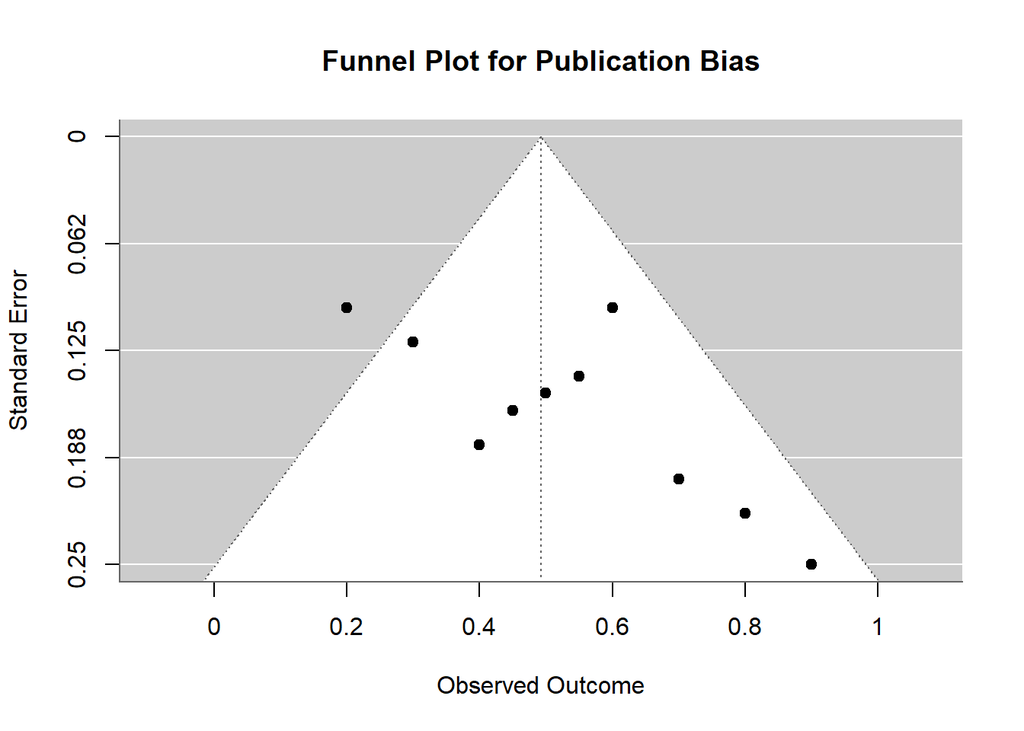

```r
funnel(res, main = "Funnel Plot for Publication Bias")
```

**General observations**

The plot shows studies spread across both sides of the vertical line (the pooled effect).

**Interpretation**

If publication bias were present, we would expect:

Missing small studies on one side of the funnel (usually those with negative or nonsignificant results).

A skewed or asymmetrical funnel shape.

## Lecture 5.3 Demonstration: Egger’s Test in R

This demonstration focuses running egger’s test using R.

**Load required library**

```r
library(metafor)
```

**Load data**

```r
proportions <- c(0.35, 0.45, 0.63, 0.69, 0.69, 0.18, 0.47, 0.55, 0.94,
                 0.67, 0.51, 0.40, 0.69, 0.70, 0.33, 0.50)
n <- c(150, 170, 131, 119, 934, 305, 368, 84, 325, 332,
       122, 97, 119, 302, 120, 185)

# Convert proportions to counts (events)
events <- round(proportions * n)
```

**Compute effect sizes: log odds ratios (logit transformed proportions)**

```r
escalc_data <- escalc(measure = "PLO", xi = events, ni = n)
```

**Running a random effect model**

```r
res <- rma(yi, vi, data = escalc_data, method = "REML")
```

**Egger’s regression test for funnel plot asymmetry**

```r
egger_test <- regtest(res, model = "rma")
```

**Print egger’s test results**

```r
print(egger_test)
```

```
##
## Regression Test for Funnel Plot Asymmetry
##
## Model:     mixed-effects meta-regression model
## Predictor: standard error
##
## Test for Funnel Plot Asymmetry: z =  0.6665, p = 0.5051
## Limit Estimate (as sei -> 0):   b = -0.3642 (CI: -2.2032, 1.4748)
```

**Interpretation**

The test statistics is not statistically significant p = 0.505 suggesting no publication bias.

## Lecture 5.5 Demonstration: Moderation - Subgroup Analysis

This demonstration focuses running sub-group analysis using R.

**Load required library**

```r
library(meta)
```

**Load data**

```r
data <- data.frame(
  study = c("Umeh & Nkombua, 2018", "Shiriyedeve et al., 2019", "Peter et al., 2022", "Oyewole et al., 2014", "Oyeyemi et al., 2013", "Dimore et al., 2023", "Wonde et al., 2022","Banson et al., 2023","Mwimo et al., 2021","Edmealem et al., 2020", "Adeniyi et al., 2014", "Taylor et al., 2023", "Oyewole et al., 2015", "Enyew et al., 2023", "Nti et al., 2016", "Adeniyi et al., 2016"),
  events = c(53, 77, 83, 82, 641, 54, 173, 46, 307, 222, 62, 39, 82, 210, 40, 92),
  sample_size = c(150, 170, 131, 119, 934, 305, 368, 84, 325, 332, 122, 97, 119, 302, 120, 185),
  country = c("South Africa", "Botswana", "Ghana", "Nigeria", "Nigeria", "Ethiopia", "Ethiopia", "Ghana","Tanzania", "Ethiopia", "Nigeria", "Ghana", "Nigeria", "Ethiopia", "Ghana", "Nigeria")
)
```

**Calculating prevalence and 95% CI**

```r
data$prevalence <- data$events / data$sample_size
data$lower_CI <- data$prevalence - 1.96 * sqrt((data$prevalence * (1 - data$prevalence)) / data$sample_size)
data$upper_CI <- data$prevalence + 1.96 * sqrt((data$prevalence * (1 - data$prevalence)) / data$sample_size)
```

**Meta-analysis with sub-group (moderator) by country**

```r
meta_analysis <- metaprop(
  event = events,
  n = sample_size,
  studlab = study,
  data = data,
  sm = "PLOGIT",
  comb.fixed = FALSE,
  comb.random = TRUE,
  hakn = TRUE,
  byvar = country,       # Subgrouping variable (moderator)
  print.byvar = TRUE     # Show subgroup labels in the forest plot
)
```

**Forest plot with subgroup analysis**

[figure not shown]

```r
forest(meta_analysis,
       xlab = "Prevalence (95% CI)",
       leftcols = c("studlab", "event", "n"),
       leftlabs = c("Study", "Events", "Sample Size"),
       col.diamond = "blue",
       col.predict = "darkgreen",
       col.by = "black",
       print.byvar = TRUE,
       overall = TRUE,
       bylab = "Country",
       fontsize = 8)
```